# Covid Analysis

Jia-li

11/29/2020

# Introduction

This analysis aims to find the pattern of association between registered number of confirmed and death covid-19 cases on 23rd, Oct.2020.

With data from CSSE and WDI R package, I selected columns of “country”, “confirmed”, “death” and “population”, while deleting all else. These variables were also scaled for checking log-transformation. Also, I deleted countries with missing values of the population, confirmed cases or death, which may raise potential data quality issue, as some countries are missing.

# Pattern of Association

Main Feature of Histograms:

- For confirmed cases, most of the distribution is between 4 and 100,000 cases, with a few observations above 7,500,000. For Death cases, most of the distribution falls within (0, 2000), with a few observations above 5,000.
- Both distributions are skewed, with a long right tail, with mean value much larger than the median value.
- For confirmed cases, there is an extreme value above 8,000,000; for death cases, there is an extreme value above 220,000. We should not drop them.

# Transformation of Variables

Variables are transformed by taking natural logarithms, and there are four models as listed below:

- level-level: death = alpha + beta * confirmed (Figure 1, in Appendix)
- log-level: ln_death = alpha + beta * confirmed (Figure 2, in Appendix)
- level-log: death = alpha + beta * ln_confirmed (Figure 3, in Appendix)
- log-log: ln_death = alpha + beta * ln_confirmed (Figure 4, in Appendix)

My final decision is the log-log model:

# Presentation of model choice

- My final decision is Simple Regression: ln_death = -4.319 + 1.029 * ln_confirmed
- When ln(confirmed cases) is zero, average ln(death cases) is -4.319, on average.
- For observations having one percent higher confirmed case, death cases are 1.029% higher, on average.

# Analysis of Hypothesis Testing

I am interested in $H_0: \beta = 0, \, H_A: \beta \neq 0$ or not in the model, with 5% significance level.

```r
hp_test
```

```
##
## Call:
## lm_robust(formula = ln_death ~ ln_confirmed, data = df, se_type = "HC2")
##
## Standard error type:  HC2
##
## Coefficients:
##              Estimate Std. Error t value  Pr(>|t|) CI Lower CI Upper  DF
## (Intercept)    -4.319    0.31301  -13.80 1.934e-29  -4.9366   -3.701 168
## ln_confirmed    1.029    0.02926   35.16 2.250e-79   0.9712    1.087 168
##
## Multiple R-squared:  0.8877 ,    Adjusted R-squared:  0.887
## F-statistic:  1236 on 1 and 168 DF,  p-value: < 2.2e-16
```

# Analysis of the residuals

```r
# Find countries with largest negative errors
neg5 <- df %>% top_n( -5 , reg1_res ) %>%
  select( country , ln_death,reg1_lny_pred, reg1_res)
print(neg5)
```

```
## # A tibble: 5 x 4
##   country   ln_death reg1_lny_pred reg1_res
##   <chr>        <dbl>         <dbl>    <dbl>
## 1 Burundi       0             2.18    -2.18
## 2 Iceland       2.40          4.29    -1.89
## 3 Qatar         5.43          7.80    -2.37
## 4 Singapore     3.33          6.97    -3.63
## 5 Sri Lanka     2.64          4.81    -2.17
```

```r
# Find countries with largest positive errors
pos5 <- df %>% top_n( 5 , reg1_res ) %>%
  select( country , ln_death,reg1_lny_pred,reg1_res)
print(pos5)
```

```
## # A tibble: 5 x 4
##   country ln_death reg1_lny_pred reg1_res
##   <chr>      <dbl>         <dbl>    <dbl>
## 1 Chad       4.56          3.15      1.41
## 2 Ecuador    9.44          8.00      1.44
## 3 Fiji       0.693        -0.721     1.41
## 4 Mexico    11.4           9.77      1.62
## 5 Yemen      6.40          3.53      2.86
```

# Executive summary

- Through investigation, the report analyzed the association between global registered number of confirmed and death covid-19 cases on 23rd, Oct.2020. There is a positive correlation between registered number of confirmed and death covid-19 cases.
- The final model is ln(death)~ln(confirmed), which reveals death cases are 1.03 percent higher, on average, for observations having 1 percent higher confirmed cases.
- The analysis can be strengthened by the invention and promotion of vaccines. Also, it might be weakened by some countries hiding true case numbers, or part of death cases caused by other pneumonia disease that are similar to Covid.

# Appendix

## Pattern of Association

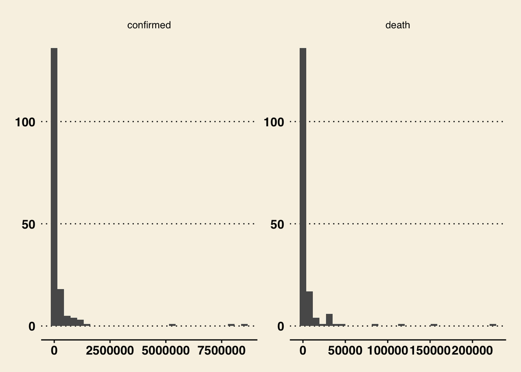

```r
# Quick check on all HISTOGRAMS
df %>%
  select(confirmed, death) %>%
  keep(is.numeric) %>%
  gather() %>%
  ggplot(aes(value)) +
  facet_wrap(~key,scales = "free") +
  geom_histogram()+
  theme_wsj() +
  scale_fill_wsj()
```

```r
summary( df %>% select(confirmed, death) )
```

```
##    confirmed           death
##  Min.   :     33   Min.   :     1
##  1st Qu.:   5182   1st Qu.:    82
##  Median :  26743   Median :   419
##  Mean   : 248265   Mean   :  6728
##  3rd Qu.: 110508   3rd Qu.:  1952
##  Max.   :8514677   Max.   :224214
```

## 1) Figure 1, death - confirmed: level-level model without scaling

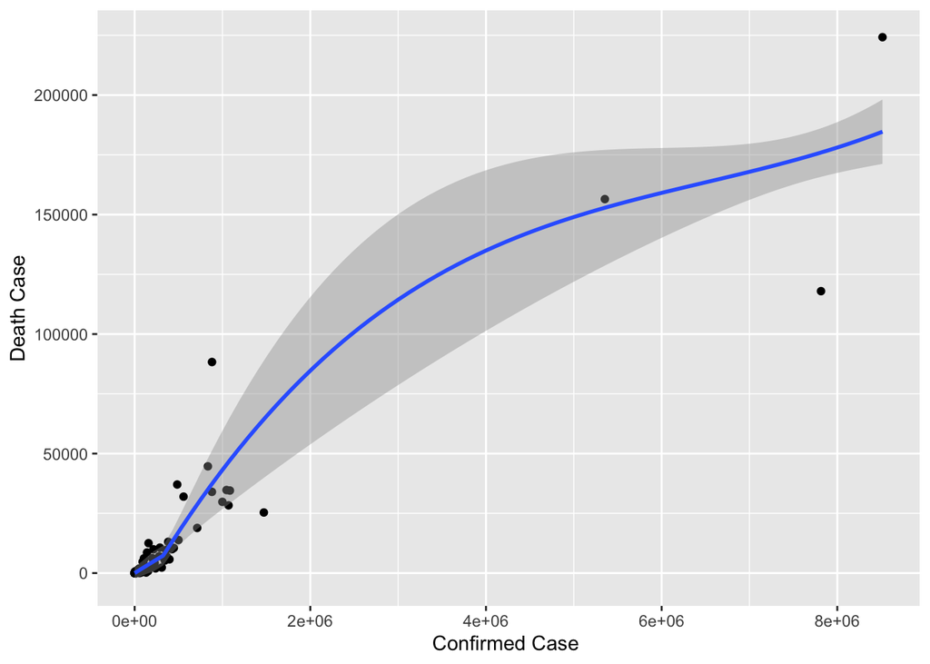

```r
ggplot( df , aes(y = death, x = confirmed)) +
  geom_point() +
  geom_smooth(method="loess")+
  scale_x_continuous(
    breaks = pretty_breaks()) +
  scale_y_continuous(breaks = pretty_breaks()) +
  labs(y = "Death Case",
       x = "Confirmed Case ")
```

## 2) Figure 2,ln_death - confirmed: log-level model

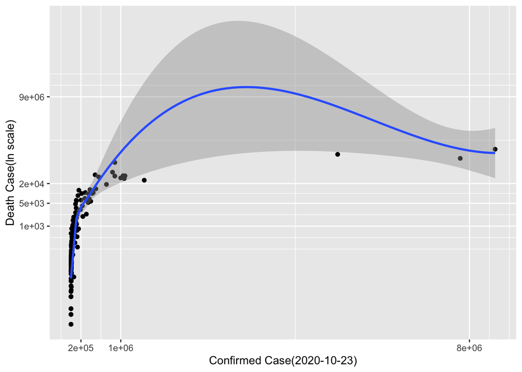

```r
ggplot( df , aes(y = death, x = confirmed ))  +
  geom_point() +
  geom_smooth(method="loess")+
  labs(y = "Death Case(ln scale)",x = "Confirmed Case(2020-10-23)") +
  scale_y_continuous( trans = log_trans(), breaks = c(0,1000,5000,20000, 9000000))+
  scale_x_continuous(breaks = c(200000,1000000,8000000))
```

## 3) Figure 3,death - ln_confirmed: level-log model

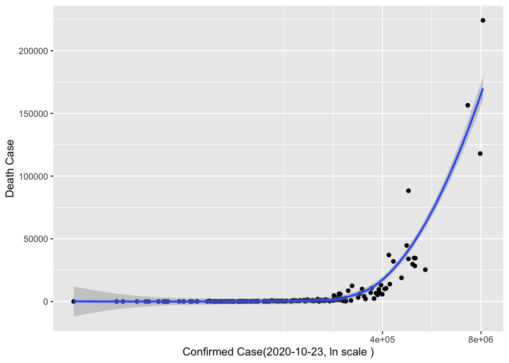

```r
ggplot( df , aes(y = death, x = confirmed)) +
  geom_point() +
  geom_smooth(method="loess")+
  labs(y = "Death Case",x = "Confirmed Case(2020-10-23, ln scale )") +
  scale_x_continuous( trans = log_trans(), breaks = c(0,400000,8000000))
```

## 4) Figure 4,ln_death - ln_confirmed: log-log model

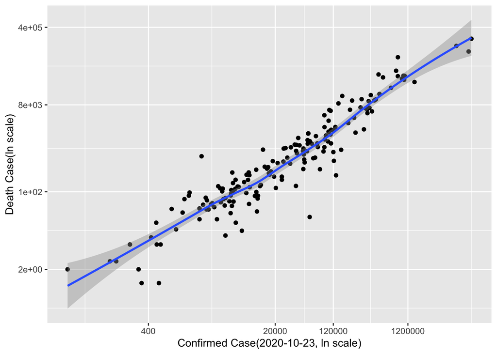

```r
ggplot( df , aes(y = death, x = confirmed ))  +
  geom_point() +
  geom_smooth(method="loess")+
  labs(y = "Death Case(ln scale)",x = "Confirmed Case(2020-10-23, ln scale)") +
  scale_x_continuous( trans = log_trans(),waiver(), breaks = c(0,400,20000,120000, 1200000))+
  scale_y_continuous( trans = log_trans(),waiver(), breaks = c(0,2,100,8000,400000))
```

# Model Estimation

Here we have four models:

## i: Simple regression

ln_death = alpha + beta * ln_confirmed

```r
reg1 <- lm_robust(ln_death ~ ln_confirmed, data = df , se_type = "HC2" )
# Summary statistics
summary( reg1 )
```

```
##
## Call:
## lm_robust(formula = ln_death ~ ln_confirmed, data = df, se_type = "HC2")
##
## Standard error type:  HC2
##
## Coefficients:
##              Estimate Std. Error t value  Pr(>|t|) CI Lower CI Upper  DF
## (Intercept)    -4.319    0.31301  -13.80 1.934e-29  -4.9366   -3.701 168
## ln_confirmed    1.029    0.02926   35.16 2.250e-79   0.9712    1.087 168
##
## Multiple R-squared:  0.8877 ,    Adjusted R-squared:  0.887
## F-statistic:  1236 on 1 and 168 DF,  p-value: < 2.2e-16
```

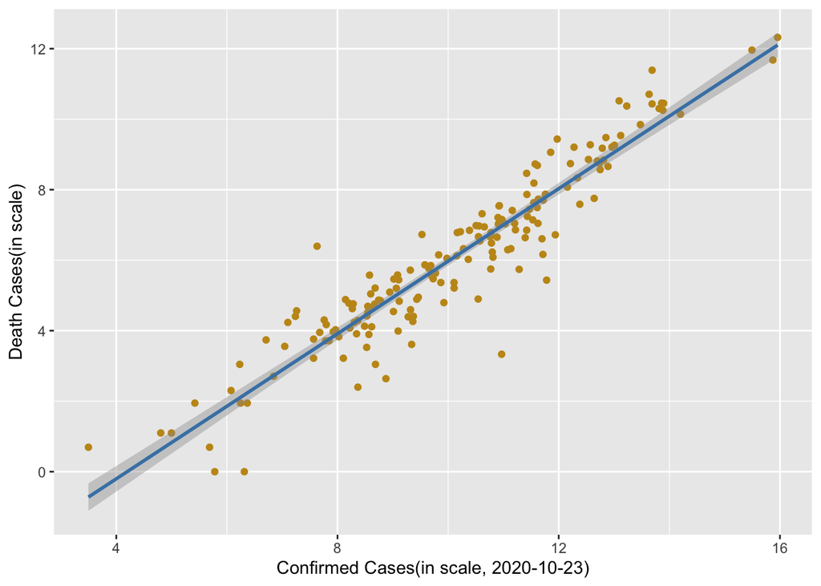

```r
# Visual inspection:
ggplot( data = df, aes( x = ln_confirmed, y = ln_death) ) +
  geom_point( color="#C4961A") +
  geom_smooth( method = lm , color = "steelblue") +
  labs(y = "Death Cases(in scale)",
       x = "Confirmed Cases(in scale, 2020-10-23)")
```

## ii: Quadratic regression

ln_death = alpha + beta_1 * ln_confirmed + beta_2 * ln_confirmed^2

```r
reg2 <- lm_robust( ln_death ~ ln_confirmed + ln_confirmed_sq , data = df )
# Summary statistics
summary( reg2 )
```

```
##
## Call:
## lm_robust(formula = ln_death ~ ln_confirmed + ln_confirmed_sq,
##     data = df)
##
## Standard error type:  HC2
##
## Coefficients:
##                 Estimate Std. Error t value Pr(>|t|) CI Lower CI Upper  DF
## (Intercept)     -2.08400   0.893825  -2.332 0.020918 -3.84865 -0.31935 167
## ln_confirmed     0.55996   0.172295   3.250 0.001396  0.21980  0.90012 167
## ln_confirmed_sq  0.02338   0.008178   2.858 0.004801  0.00723  0.03952 167
##
## Multiple R-squared:  0.8921 ,    Adjusted R-squared:  0.8908
## F-statistic: 719.7 on 2 and 167 DF,  p-value: < 2.2e-16
```

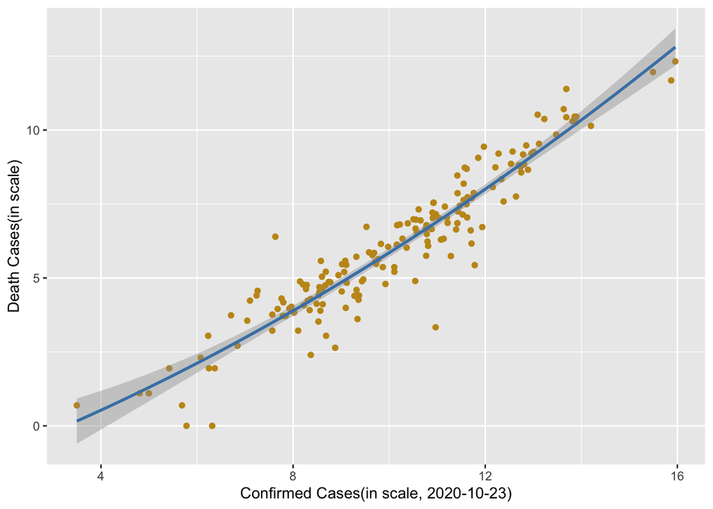

```r
# Visual inspection:
ggplot( data = df, aes( x = ln_confirmed, y = ln_death ) ) +
  geom_point( color="#C4961A") +
  geom_smooth( formula = y ~ poly(x,2) , method = lm , color = "steelblue") +
  labs(y = "Death Cases(in scale)",
       x = "Confirmed Cases(in scale, 2020-10-23)")
```

## iii: Piecewise linear spline regression

```r
reg3 <- lm_robust(ln_death ~ lspline( ln_confirmed , c(8,12,14)), data = df )
# Summary statistics
summary(reg3)
```

```
##
## Call:
## lm_robust(formula = ln_death ~ lspline(ln_confirmed, c(8, 12,
##     14)), data = df)
##
## Standard error type:  HC2
##
## Coefficients:
##                                      Estimate Std. Error t value  Pr(>|t|)
## (Intercept)                           -3.4058    0.91774  -3.711 2.818e-04
## lspline(ln_confirmed, c(8, 12, 14))1   0.9178    0.11997   7.651 1.579e-12
## lspline(ln_confirmed, c(8, 12, 14))2   0.9618    0.05711  16.842 1.126e-37
## lspline(ln_confirmed, c(8, 12, 14))3   1.5356    0.13668  11.235 4.123e-22
## lspline(ln_confirmed, c(8, 12, 14))4   0.6159    0.14956   4.118 6.021e-05
##                                      CI Lower CI Upper  DF
## (Intercept)                           -5.2179  -1.5938 165
## lspline(ln_confirmed, c(8, 12, 14))1   0.6809   1.1547 165
## lspline(ln_confirmed, c(8, 12, 14))2   0.8491   1.0746 165
## lspline(ln_confirmed, c(8, 12, 14))3   1.2657   1.8055 165
## lspline(ln_confirmed, c(8, 12, 14))4   0.3206   0.9112 165
##
## Multiple R-squared:  0.8953 ,    Adjusted R-squared:  0.8927
## F-statistic: 549.1 on 4 and 165 DF,  p-value: < 2.2e-16
```

[figure not shown]

```r
# Visual inspection:
ggplot( data = df, aes( x = ln_confirmed, y = ln_death ) ) +
  geom_point(color = "#C4961A") +
  geom_smooth( formula = y ~ lspline(x, cutoff) , method = lm , color = "steelblue" ) +
  labs(y = "Death Cases(in scale)",
       x = "Confirmed Cases(in scale, 2020-10-23)")
```

## iv: Weighted linear regression, using population as weights.

ln_death = alpha + beta * ln_confirmed, weights: population

```r
reg4 <- lm_robust(ln_death ~ ln_confirmed, data = df , weights = population)
# Summary statistics
summary( reg4 )
```

```
##
## Call:
## lm_robust(formula = ln_death ~ ln_confirmed, data = df, weights = population)
##
## Weighted, Standard error type:  HC2
##
## Coefficients:
##              Estimate Std. Error t value  Pr(>|t|) CI Lower CI Upper  DF
## (Intercept)   -3.0510    0.77349  -3.944 1.173e-04  -4.5780   -1.524 168
## ln_confirmed   0.9506    0.06153  15.449 4.477e-34   0.8291    1.072 168
##
## Multiple R-squared:  0.9294 ,    Adjusted R-squared:  0.929
## F-statistic: 238.7 on 1 and 168 DF,  p-value: < 2.2e-16
```

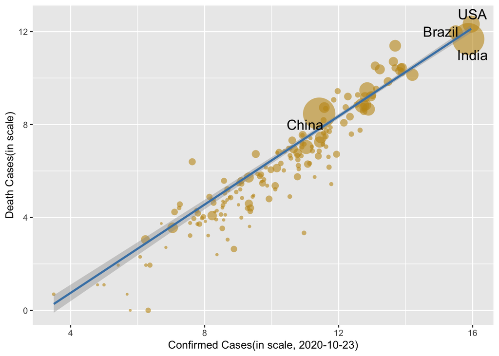

```r
# Visual inspection:
ggplot(data = df, aes(x = ln_confirmed, y = ln_death)) +
  geom_point(data = df, aes(size=population),  color = "#C4961A", shape = 16, alpha = 0.6,  show.legend=F) +
  geom_smooth(aes(weight = population), method = "lm", color= "steelblue")+
  scale_size(range = c(1, 15)) +
  coord_cartesian(ylim = c(0, 12.5)) +
  labs(y = "Death Cases(in scale)",
       x = "Confirmed Cases(in scale, 2020-10-23)") +
  annotate("text", x = 16, y = 11, label = "India", size=5)+
  annotate("text", x = 11, y = 8, label = "China", size=5)+
  annotate("text", x = 16,  y = 12.75, label = "USA", size=5) +
  annotate("text", x = 15.05,  y = 12, label = "Brazil", size=5)
```

# Summary of All models

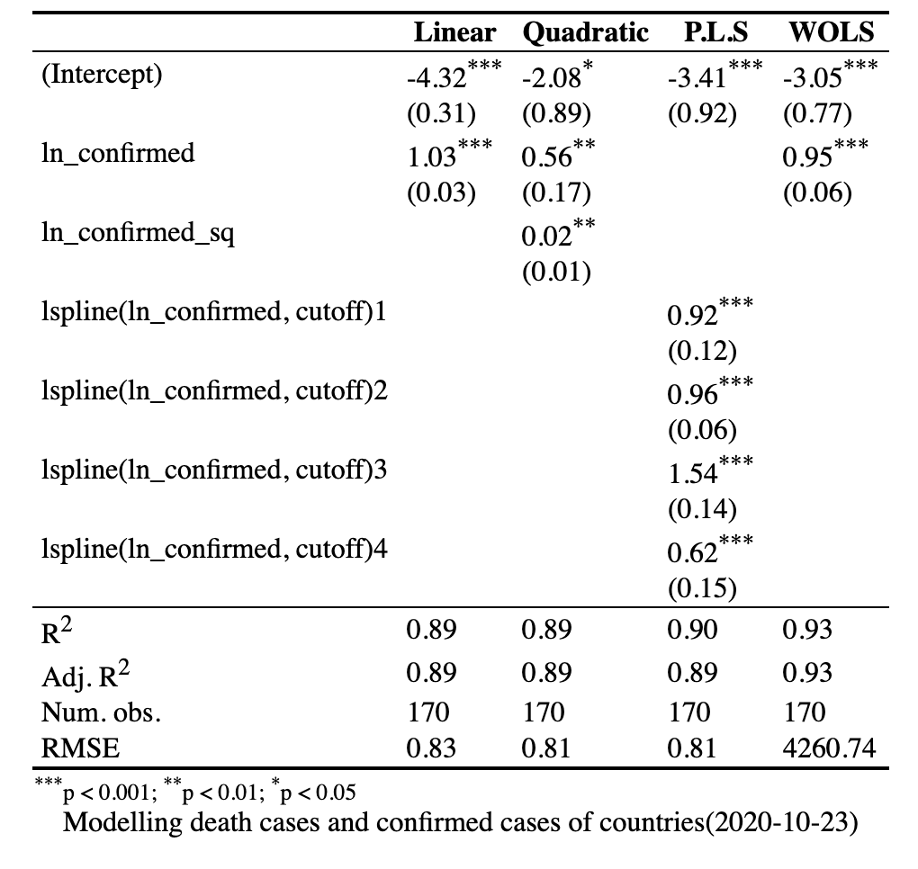

model comparision

## Model Summaries

With model comparison table and plot visualization, we can conclude:

- For linear regression:
  - For observations having one percent higher confirmed case, death cases are 1.029% higher, on average.
  - r-square = 0.89 means 89% of the variation in ln(death cases) is captured by the regression, and 11% is left for residual variation.
- For quadratic regression:
  - 0.02 is positive; so the relationship is convex
  - r-square = 0.89 means 89% of the variation in ln(death cases) is captured by the regression, and 11% is left for residual variation.
- For Piecewise linear spline regression:
  - Among observations with ln(confirmed_case) values less than 8, ln(death_cases) is 0.92 units higher, on average, for observations with one unit higher ln(confirmed_case) value.
  - Among observations with ln(confirmed_case) values between 8 and 12, ln(death_cases) is 0.96 units higher, on average, for observations with one unit higher ln(confirmed_case) value.
  - Among observations with ln(confirmed_case) values between 12 and 14, ln(death_cases) is 1.54 units higher, on average, for observations with one unit higher ln(confirmed_case) value.
  - Among observations with ln(confirmed_case) values above 14, ln(death_cases) is 0.62 units higher, on average, for observations with one unit higher ln(confirmed_case) value.
  - For Weighted linear regression: USA, Brazil and India are in the most severe covid pandemic situations.

## Final Choice

Based on model comparison, my chosen model is reg1(ln_death ~ ln_confirmed):

- Substantive:
  - The other three make little change to what is basically a linear association: they are over-complicated, to some degree.
- Statistical:
  - Compared with other three, simple regression(log-log) model is easy to interpret.
  - Log-log model has a comparatively high R-square and captures variation well.